# Section 1: Setup and Data Loading

```python
import numpy as np
import pandas as pd
from sklearn.svm import SVR
from sklearn.model_selection import train_test_split, cross_val_score, learning_curve, GridSearchCV
from sklearn.preprocessing import StandardScaler
from sklearn.metrics import mean_absolute_error, mean_squared_error, r2_score
from sklearn.decomposition import PCA
import matplotlib.pyplot as plt
from mpl_toolkits.mplot3d import Axes3D
```

```python
path = 'data_clean.csv'

df_original = pd.read_csv(path)
```

```python
# Overview of variables and NAs
list(df_original)

df_original.info()
```

```
<class 'pandas.core.frame.DataFrame'>
RangeIndex: 891 entries, 0 to 890
Data columns (total 13 columns):
 #   Column                 Non-Null Count  Dtype
---  ------                 --------------  -----
 0   Trip_Distance_km       891 non-null    float64
 1   Time_of_Day            891 non-null    object
 2   Day_of_Week            891 non-null    object
 3   Passenger_Count        891 non-null    float64
 4   Traffic_Conditions     891 non-null    object
 5   Weather                891 non-null    object
 6   Base_Fare              891 non-null    float64
 7   Per_Km_Rate            891 non-null    float64
 8   Per_Minute_Rate        891 non-null    float64
 9   Trip_Duration_Minutes  891 non-null    float64
 10  Trip_Price             891 non-null    float64
 11  Trip_Distance_km_log   891 non-null    float64
 12  Trip_Price_log         891 non-null    float64
dtypes: float64(9), object(4)
memory usage: 90.6+ KB
```

# Section 2: Data Preparation for Modeling

```python
# Create a copy to avoid modifying the original dataframe
df_linear_model = df_original.copy()

# Drop the original log transformed columns
df_linear_model = df_linear_model.drop(['Trip_Distance_km_log', 'Trip_Price_log'], axis=1)

# Create dummy variables for categorical columns
categorical_columns = ['Time_of_Day', 'Day_of_Week', 'Traffic_Conditions', 'Weather']

# Create dummies and drop first category for each variable
for column in categorical_columns:
    dummies = pd.get_dummies(df_linear_model[column], prefix=column, drop_first=True)
    df_linear_model = pd.concat([df_linear_model, dummies], axis=1)
    df_linear_model = df_linear_model.drop(column, axis=1)

df_linear_model.info()
```

```
<class 'pandas.core.frame.DataFrame'>
RangeIndex: 891 entries, 0 to 890
Data columns (total 15 columns):
 #   Column                     Non-Null Count  Dtype
---  ------                     --------------  -----
 0   Trip_Distance_km           891 non-null    float64
 1   Passenger_Count            891 non-null    float64
 2   Base_Fare                  891 non-null    float64
 3   Per_Km_Rate                891 non-null    float64
 4   Per_Minute_Rate            891 non-null    float64
 5   Trip_Duration_Minutes      891 non-null    float64
 6   Trip_Price                 891 non-null    float64
 7   Time_of_Day_Evening        891 non-null    bool
 8   Time_of_Day_Morning        891 non-null    bool
 9   Time_of_Day_Night          891 non-null    bool
 10  Day_of_Week_Weekend        891 non-null    bool
 11  Traffic_Conditions_Low     891 non-null    bool
 12  Traffic_Conditions_Medium  891 non-null    bool
 13  Weather_Rain               891 non-null    bool
 14  Weather_Snow               891 non-null    bool
dtypes: bool(8), float64(7)
memory usage: 55.8 KB
```

# Section 3: Feature Scaling and Train-Test Split

```python
#Scale numerical features only (not using log)
numerical_columns = ['Trip_Distance_km', 'Passenger_Count', 'Base_Fare',
                    'Per_Km_Rate', 'Per_Minute_Rate', 'Trip_Duration_Minutes', 'Trip_Price']


#set the scaler
scaler = StandardScaler()
df_model_scaled = df_linear_model.copy()
df_model_scaled[numerical_columns] = scaler.fit_transform(df_linear_model[numerical_columns])

X = df_model_scaled.drop('Trip_Price', axis=1)
y = df_model_scaled['Trip_Price']

# Transform booleans in integer for better handling
bool_columns = X.select_dtypes(include='bool').columns
X[bool_columns] = X[bool_columns].astype(int)

X_train, X_test, y_train, y_test = train_test_split(X, y, test_size=0.2, random_state=42)
```

# Section 4: Initial SVR Model Fitting and Evaluation

```python
# Train the model
svm_model = SVR(kernel='linear')
svm_model.fit(X_train, y_train)
```

```
SVR(kernel='linear')
```

## Key SVM Parameters to Tune

When using **Support Vector Machines (SVM)**, several hyperparameters can significantly affect model performance. Here are the most important ones to consider:

### a. **Kernel Type** (`kernel`)

- `'linear'`: Best suited for **linearly separable** data.
- `'rbf'` *(default)*: **Radial Basis Function**, effective for **non-linear** relationships.
- `'poly'`: **Polynomial kernel**, introduces non-linearity through polynomial transformations.
- `'sigmoid'`: Acts like a **neural network activation** function.

### b. **Regularization Parameter** (`C`)

Controls the trade-off between a smooth decision boundary and correct classification of training examples.

- **High `C`**:
  - Smaller margin
  - Tries to classify all training points correctly
  - **Low bias, high variance**
- **Low `C`**:
  - Larger margin
  - Allows misclassification of some training points
  - **High bias, low variance**

### c. **Kernel Coefficient** (`gamma`)

Defines how far the influence of a single training example reaches.

- **Low `gamma`**:
  - Influence is far-reaching
  - Model is smoother and simpler
  - **High bias**
- **High `gamma`**:
  - Influence is close
  - Model fits the training data more closely
  - **High variance / overfitting risk**

### d. **Epsilon** (`epsilon`) — *used in SVR (Support Vector Regression)*

Defines the margin of tolerance where no penalty is given for errors.

- **Small `epsilon`**:
  - Model follows training data very closely
  - Potential for overfitting

### e. **Degree** (`degree`) — *only for `'poly'` kernel*

Defines the degree of the polynomial function used.

- **Higher degree**:
  - More flexible decision boundary
  - Increased risk of **overfitting**

```python
# Make predictions
y_pred = svm_model.predict(X_test)

# Evaluate the model
mse = mean_squared_error(y_test, y_pred)
r2 = r2_score(y_test, y_pred)

print(f"Mean Squared Error: {mse:.4f}")
print(f"R-squared: {r2:.4f}")
```

```
Mean Squared Error: 0.1068
R-squared: 0.8964
```

```python
#Support vectors (if the model is fitted with support vectors)
print("\nSupport Vectors:", svm_model.support_vectors_.shape)
```

```
Support Vectors: (446, 14)
```

# Section 5: Visualizing Initial SVR Model and Support Vectors

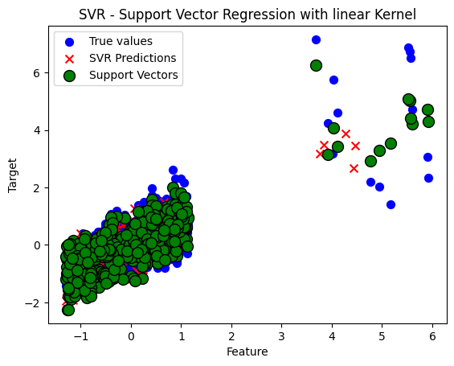

```python
#Plotting the graph of Support Vectors
svm_model.fit(X_train, y_train)

# extract support vectors
sv = svm_model.support_vectors_

# Make predictions using X_test
y_pred = svm_model.predict(X_test)


# Plot predictions (using X_train e y_train to compare with true values)
plt.scatter(X_train.iloc[:, 0], y_train, c='blue', label="True values", s=50, marker='o')  # .iloc to access to columns
plt.scatter(X_test.iloc[:, 0], y_pred, c='red', label="SVR Predictions", s=50, marker='x')

# plot support vectors (2D visualization)
plt.scatter(sv[:, 0], svm_model.predict(sv), color='green', s=100, edgecolors='k', label="Support Vectors", marker='o')

plt.xlabel("Feature")
plt.ylabel("Target")
plt.title("SVR - Support Vector Regression with linear Kernel")
plt.legend()
plt.show()
```

# Section 6: PCA Visualization of SVR Model

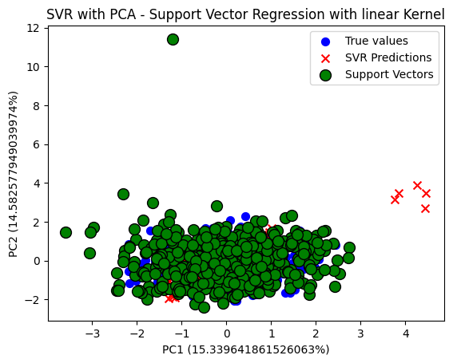

```python
# Use PCA to reduce the predictors' space to 2D
pca = PCA(n_components=2)
X_train_2d = pca.fit_transform(X_train)

# Predictions using PCA
y_pred = svm_model.predict(X_test)

# Find the Support Vectors in the new 2D space
sv = svm_model.support_vectors_
sv_2d = pca.transform(sv)

# Plot the data
plt.scatter(X_train_2d[:, 0], X_train_2d[:, 1], c='blue', label="True values", s=50, marker='o')
plt.scatter(X_test.iloc[:, 0], y_pred, c='red', label="SVR Predictions", s=50, marker='x')

# Visualize the Support Vectors in the new 2D space
plt.scatter(sv_2d[:, 0], sv_2d[:, 1], color='green', s=100, edgecolors='k', label="Support Vectors", marker='o')

plt.xlabel('PC1 ({}%)'.format(pca.explained_variance_ratio_[0]*100))
plt.ylabel('PC2 ({}%)'.format(pca.explained_variance_ratio_[1]*100))
plt.title("SVR with PCA - Support Vector Regression with linear Kernel")
plt.legend()
plt.show()
```

# Section 7: Hyperparameter Tuning with Grid Search

```python
from sklearn.model_selection import GridSearchCV

# Define parameter grid
param_grid = {
    'C': [0.1, 1, 10, 100],
    'gamma': [0.01, 0.1, 1, 10],
    'kernel': ['rbf', 'linear'],
    'epsilon': [0.1, 0.5, 1]
}

# Grid search
grid_search = GridSearchCV(SVR(), param_grid, cv=5, scoring='neg_mean_squared_error')
grid_search.fit(X_train, y_train)

# Best parameters
print("Best parameters found: ", grid_search.best_params_)

# Best model
best_svm = grid_search.best_estimator_
```

```
Best parameters found:  {'C': 100, 'epsilon': 0.1, 'gamma': 0.01, 'kernel': 'rbf'}
```

# Section 8: evaluating the Optimized Model

```python
# Make predictions
y_pred = best_svm.predict(X_test)

# Evaluate the model
mae = mean_absolute_error(y_test, y_pred)
mse = mean_squared_error(y_test, y_pred)
r2 = r2_score(y_test, y_pred)

# Best parameters and performance
print("Best parameters found: ", grid_search.best_params_)
#print(f"Mean Absolute Error (MAE): {mae}")
print(f"Mean Squared Error: {mse:.4f}")
#print(f"Root Mean Squared Error: {rmse:.4f}")
print(f"R-squared: {r2:.4f}")
```

```
Best parameters found:  {'C': 100, 'epsilon': 0.1, 'gamma': 0.01, 'kernel': 'rbf'}
Mean Squared Error: 0.0054
R-squared: 0.9948
```

```python
#Support vectors (if the model is fitted with support vectors)
print("\nSupport Vectors:", best_svm.support_vectors_.shape)
```

```
Support Vectors: (62, 14)
```

**Support Vectors Interpretations**

There are 62 support vectors, each one with 14 features. This means that there are 62 data points defining the decision boundary of your SVM model. The more support vectors there are, the more complex and detailed your model is. However, be cautious, as having too many support vectors may indicate that the model is overfitting.

# Section 9: Model Evaluation Visualizations

**Prediction vs Actual Plot** You can plot the predicted values against the actual values to see how well the model is performing.

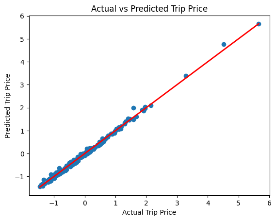

```python
import matplotlib.pyplot as plt

plt.scatter(y_test, y_pred)
plt.plot([min(y_test), max(y_test)], [min(y_test), max(y_test)], color='red', linewidth=2)
plt.xlabel('Actual Trip Price')
plt.ylabel('Predicted Trip Price')
plt.title('Actual vs Predicted Trip Price')
plt.show()
```

A **residual plot** helps you check if there is any pattern in the residuals (errors), which could suggest the need for a better model.

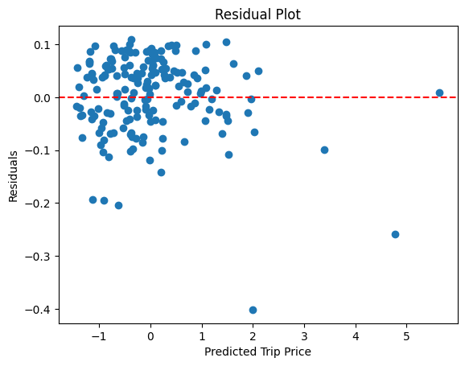

```python
residuals = y_test - y_pred

plt.scatter(y_pred, residuals)
plt.axhline(y=0, color='r', linestyle='--')
plt.xlabel('Predicted Trip Price')
plt.ylabel('Residuals')
plt.title('Residual Plot')
plt.show()
```

**Learning Curve (For Overfitting/Underfitting Check)**. A learning curve shows how the model performance changes as the training size increases. It helps you detect overfitting or underfitting

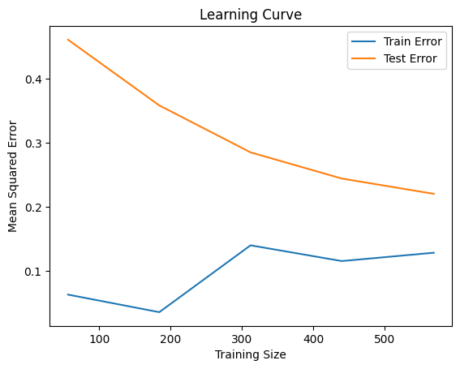

```python
train_sizes, train_scores, test_scores = learning_curve(SVR(), X_train, y_train, cv=5, scoring='neg_mean_squared_error')

train_scores_mean = -train_scores.mean(axis=1)
test_scores_mean = -test_scores.mean(axis=1)

plt.plot(train_sizes, train_scores_mean, label='Train Error')
plt.plot(train_sizes, test_scores_mean, label='Test Error')
plt.xlabel('Training Size')
plt.ylabel('Mean Squared Error')
plt.title('Learning Curve')
plt.legend()
plt.show()
```

# Section 10: Visualizing the Optimized Model with PCA

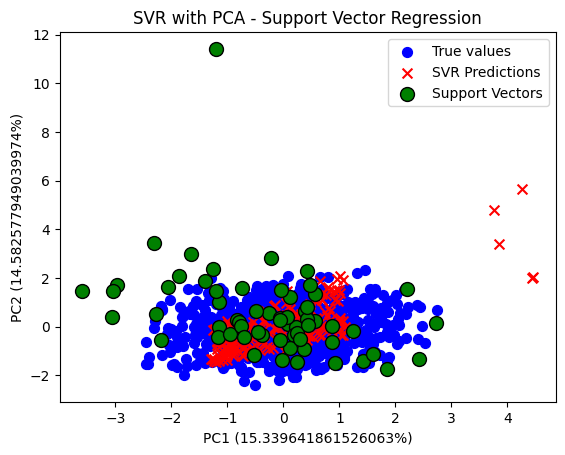

```python
# Apply PCA to reduce predictors space
pca = PCA(n_components=2)
X_train_2d = pca.fit_transform(X_train)

# Predict using PCAs
y_pred = best_svm.predict(X_test)

# Extract the Support Vector from the new 2D
sv = best_svm.support_vectors_
sv_2d = pca.transform(sv)

# Plot the data
plt.scatter(X_train_2d[:, 0], X_train_2d[:, 1], c='blue', label="True values", s=50, marker='o')
plt.scatter(X_test.iloc[:, 0], y_pred, c='red', label="SVR Predictions", s=50, marker='x')

# Plot support vectors in the 2D space
plt.scatter(sv_2d[:, 0], sv_2d[:, 1], color='green', s=100, edgecolors='k', label="Support Vectors", marker='o')

plt.xlabel('PC1 ({}%)'.format(pca.explained_variance_ratio_[0]*100))
plt.ylabel('PC2 ({}%)'.format(pca.explained_variance_ratio_[1]*100))
plt.title("SVR with PCA - Support Vector Regression")
plt.legend()
plt.show()
```

# Section 11: Visualizing the Optimized Model with Original Features

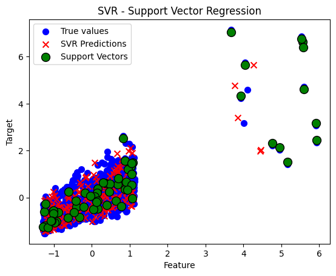

```python
#Plotting the graph of Support Vectors
best_svm.fit(X_train, y_train)

# Find support vectors
sv = best_svm.support_vectors_

# Make predictions on the test set using X_test
y_pred = best_svm.predict(X_test)


# Plot predictions
plt.scatter(X_train.iloc[:, 0], y_train, c='blue', label="True values", s=50, marker='o')  # usa .iloc per accedere alle colonne
plt.scatter(X_test.iloc[:, 0], y_pred, c='red', label="SVR Predictions", s=50, marker='x')

# Plot the support vectors in a 2D space
plt.scatter(sv[:, 0], best_svm.predict(sv), color='green', s=100, edgecolors='k', label="Support Vectors", marker='o')

plt.xlabel("Feature")
plt.ylabel("Target")
plt.title("SVR - Support Vector Regression")
plt.legend()
plt.show()
```

# Section 12: PCA Component Analysis

```python
# Loadings (how each variabile contributes to the PCA)
loadings = pd.DataFrame(pca.components_.T,
                        columns=['PC1', 'PC2'],
                        index=X_train.columns)

print("Loadings of PCA:")
print(loadings)
```

```
Loadings of PCA:
                                PC1       PC2
Trip_Distance_km          -0.375039  0.382476
Passenger_Count            0.645986  0.066857
Base_Fare                  0.056606 -0.132970
Per_Km_Rate                0.434674  0.301544
Per_Minute_Rate            0.045478  0.849642
Trip_Duration_Minutes      0.496954 -0.123416
Time_of_Day_Evening        0.002615  0.010906
Time_of_Day_Morning        0.020253 -0.047506
Time_of_Day_Night          0.000397  0.022977
Day_of_Week_Weekend        0.002906 -0.003475
Traffic_Conditions_Low     0.017493  0.010625
Traffic_Conditions_Medium  0.001152 -0.015531
Weather_Rain               0.004792  0.011371
Weather_Snow               0.010697  0.010496
```

# Section 14: 3D Visualization of SVR Model

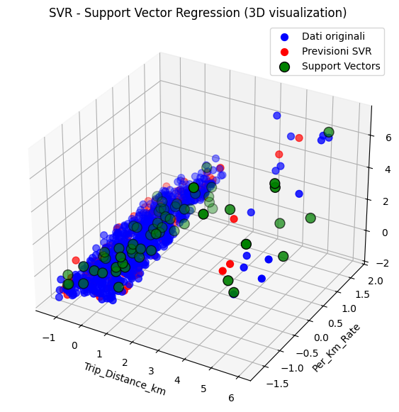

```python
# Create a 3D graph
fig = plt.figure(figsize=(10, 7))
ax = fig.add_subplot(111, projection='3d')

# Set up the name of the two features to plot
feature_1 = 'Trip_Distance_km'
feature_2 = 'Per_Km_Rate'

# Scatter plot of training values (X_train e y_train)
ax.scatter(X_train[feature_1], X_train[feature_2], y_train, c='blue', label="Dati originali", s=50)

# Scatter plot of predictions (X_test e y_pred)
ax.scatter(X_test[feature_1], X_test[feature_2], y_pred, c='red', label="Previsioni SVR", s=50)

# Plot support vectors
ax.scatter(sv[:, 0], sv[:, 1], best_svm.predict(sv), color='green', s=100, edgecolors='k', label="Support Vectors", marker='o')

# Set up labels and title
ax.set_xlabel(feature_1)
ax.set_ylabel(feature_2)
ax.set_zlabel("Target/Trip Price")
ax.set_title("SVR - Support Vector Regression (3D visualization)")
ax.legend()

# Show the plot
plt.show()
```